# Visualizations of Data Concerning COVID-19 in the United States

Ethan Rosenbaum and Yujing Wang

2/25/2022

All Data Sourced from “https://covid.cdc.gov/covid-data-tracker/#cases_casesper100klast7days” and “https://covid.cdc.gov/covid-data-tracker/#vaccinations_vacc-total-admin-rate-total”

# Chart 1: Density Curve of Death Rates

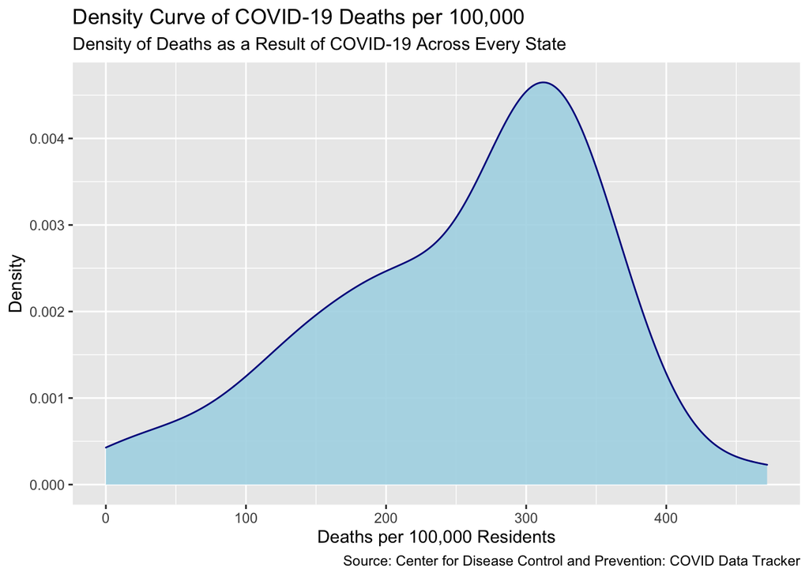

```r
testingdata <- read.csv("cases_deaths_and_testing_by_state.csv")
vaccinedata <- read.csv("covid19_vaccinations.csv")
data <- left_join(testingdata,vaccinedata)
data <- data[-c(36), ]
deaths <- as.numeric(data$Death.Rate.per.100000)
dens <- ggplot(data, aes(x=deaths, color = deaths)) +
  geom_density(color="darkblue", fill="lightblue", alpha = 0.9) +
  labs(title = "Density Curve of COVID-19 Deaths per 100,000",
       x = "Deaths per 100,000 Residents",
       y = "Density",
       subtitle = "Density of Deaths as a Result of COVID-19 Across Every State",
       caption = "Source: Center for Disease Control and Prevention: COVID Data Tracker")
dens
```

The density plot above displays the various concentration of death rates per 100,000 residents as a culmination of the data of each state and territory within the U.S. The wide variety could be evidence of the widely disparate responses to the COVID-19 pandemic by different state governments, or perhaps different levels of death data collection by different states.